# Week 5 Learning Journal

Published

February 7, 2024

## Section 1: Geo-processing and Overlay Analysis

Tutorial name(s) and link(s):

- [Get started Using Geoprocessing Tools](https://pro.arcgis.com/en/pro-app/get-started/use-geoprocessing-tools.htm) (approximately 45 minutes)
- [Introduction to Overlay Analysis](https://www.esri.com/training/catalog/5f98b45242708d58e8ca7587/introduction-to-overlay-analysis/) (approximately 75 minutes)

Insight: ArcGIS provides and extensive array of tools and processes to combine and join data in many ways, there is almost always a ‘best’ tool for the job since many are specifically designed for a specific purpose. Taking the time to understand you current features, your question, and what you need to to answer you question can save you a huge headache later.

Screenshot(s):

[figure not shown]

Intro to overlay Analysis final map

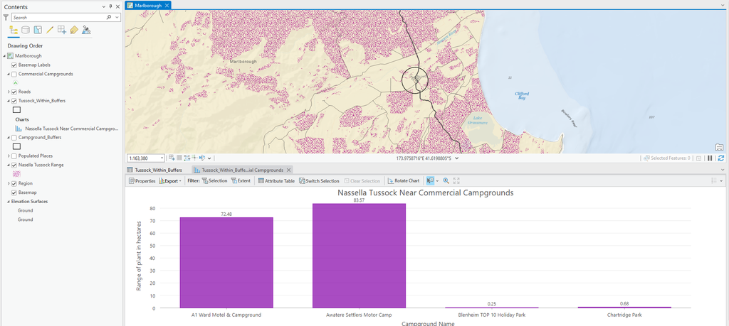

Geoprocessing tools Final map + chart

[figure not shown]

Intro to Overlays Certificate

### Essential Geoprocessing Table

| **Tool** | **What it does** | **Example** |
| --- | --- | --- |
| Buffer | Creates a new feature layer where each feature is a specified distance away from the original features. | Generating a 500-meter buffer around all rivers to delineate a protected area. |
| Calculate Geometry | Allows for the calculation of geometric properties (such as area, length, or coordinates) of features within a layer. | Calculating the area of each polygon in a land use dataset. |
| Clip | Cuts out a portion of one feature layer using the shape of another layer as the boundary. | Clipping a national forest layer to the boundaries of a specific state. |
| Dissolve | Aggregates features based on specified attributes, removing boundaries to create a new layer of larger, simplified polygons. | Dissolving a county-level map into a state-level map by merging all counties within each state. |
| Erase | Creates a feature class by overlaying the input features with the polygons of the erase features | select only a portion of a feature class by excluding a section of overlap |
| Intersect | Computes a geometric intersection of the input features | Points within a polygon |
| Merge | Combines multiple input datasets into a single, new output dataset. | Merging separate layers of lakes, rivers, and ponds into a single water bodies layer. |
| Select by location | Selects features in a layer based on their spatial relationship to features in another layer. | Selecting all buildings within 1 kilometer of a river. |
| Select by attribute | Selects features in a layer based on a query applied to their attributes. | Selecting all cities with a population greater than 100,000. |
| Spatial Join | Joins attributes from one feature to another based on the spatial relationship | Grab data from one class to another |
| Summarize within | Aggregates data from one layer within the boundaries of another layer, summarizing the information. | Calculating the total population within each zip code area by summarizing individual household data. |
| Union | Computes a geometric union of the input features | join features but maintain integrity of original boundaries. |

### Statements of Understanding

- The Spatial Analysis Approach  
  Its a very similar to a general datascience or economic consulting workflow.

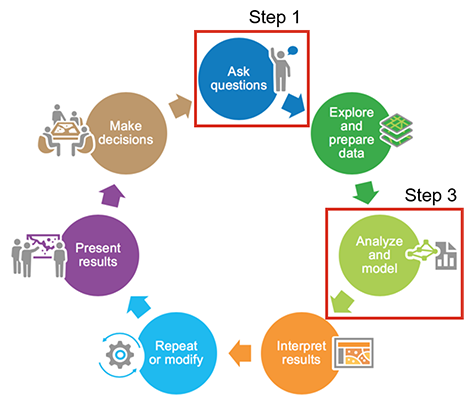

- Strategies for finding the appropriate tool.

  Know your stuff. Then evaluate the types of data you are dealing with, what you need the final output to be either as an attribute table or resulting feature class and determine from there which tools are even possible to use and then which best fulfills your needs.
- How to create graphs from processed data.  
  Right click layer in contents, choose ‘create a graph’, or use the analysis tab at the top
- How to view your geoprocessing history.  
  In the Geoprocessing group, click ‘History.’
- How to use vector overlay tools to assign information from one feature to another.

  They allow us to enrich one (or create a new) feature layer with data from another by utilizing their spatial relationships or unique keys, essential for tasks like environmental management and urban planning.

## Section 2: Data Sources

Knowing where to find and download geospatial data can be a big challenge. In this section, list the internet data sources that you use during the semester and any others that you encounter on your own.

- ESRI Tutorial Download

## Section 3: Class How To’s

In this section include documents provided in class (e.g., how to prepare a table for use in GIS, how to georeference) or notes about a specific tool you learn about that’s not part of the assigned topics.

*Personal Note*

Refer to demo folders in W5 for some extra stuff